# l6_quant_ii_en2

## Step 4: correlation

$Cor(x,y) = \frac{Cov(x,y)}{sd(x)sd(y)}$ can also be written as $r(x,y)$

Cor or r: Not only the *direction*, but the *strength* of the **linear** association

- The **sign** indicates the direction, just as with covariance
- The **absolute value** indicates the strength, from 0 (nothing) to 1 (a perfect line)

It is useful for comparing associations between variables measured on different scales

**Rough rules of thumb** (they depend on the discipline)

| $\lvert r \rvert$ | Reading |
| --- | --- |
| 0.1 | weak |
| 0.3 | moderate |
| 0.5 or more | strong |

```r
cor_xy <- cov_xy / (sqrt(var_x) * sqrt(var_y))
cor_xy
```

```
[1] -0.8944272
```

Let’s check with R’s functions

```r
c(var(ejemplo$educacion), var(ejemplo$ia), cov(ejemplo$educacion, ejemplo$ia), cor(ejemplo$educacion, ejemplo$ia))
```

```
[1] 13.3333333  0.6666667 -2.6666667 -0.8944272
```

**$r^2$** is the proportion of variance shared by the two variables

$r = -0{.}89$ is a strong negative association. And $r^2 = 0{.}80$, meaning that education “explains” 80% of the variance in concern about AI in these 4 cases

## Correlation: A visual example and limitation

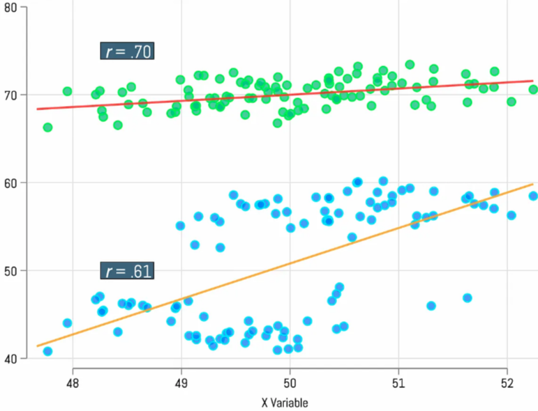

**Limitations:** Correlation tells us about the direction (neg, pos) and the linearity (robustness) of the association, but it doesn’t give us a clean interpretation of the association—**regression will help us with that**

**Regression, por fin**

## Regression

[figure not shown]

## The logic of regression

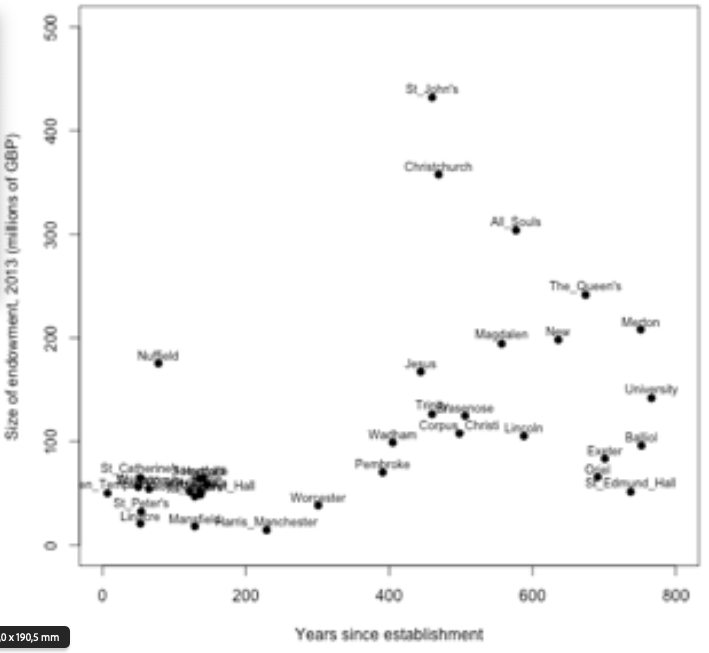

The goal is to **summarize** the relationship between both variables

How do we identify the line that best summarizes the association between both variables?

**Linear regression** (OLS, ordinary least squares) is the one that minimizes the total or average of the squared errors, the distance of the points to the line

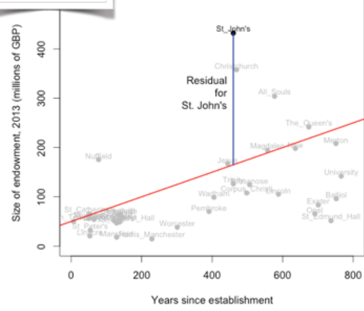

## Bivariate regression, components

$y_i = a + \beta x_i + u_i$

What do we mean by minimizing the error?

$\min \sum \hat{u_i}^2$

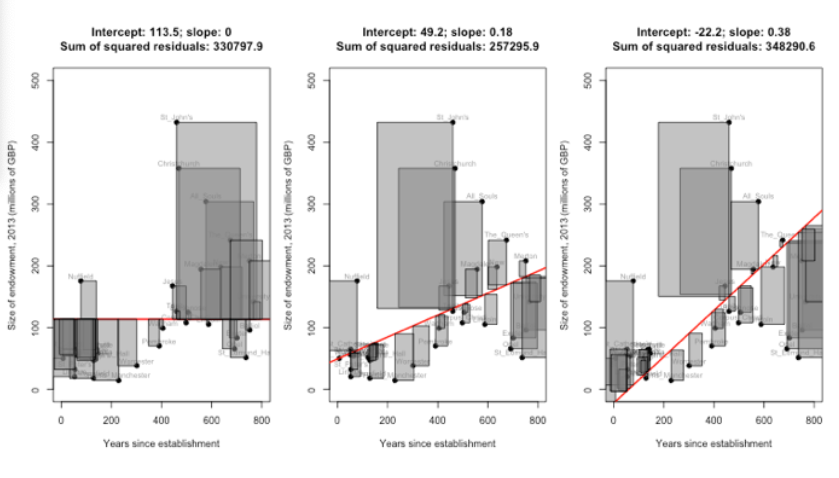

Other components

- $\hat{\alpha}$: intercept, the starting point of the line on the y-axis when x = 0
- $\hat{\beta} = \frac{Cov(x,y)}{Var(x)}$: the slope of the line

## Properties of regression

The sign of the covariance, the correlation and the regression’s $\hat{\beta}$ is the same

```r
cov(ia_ideologia$ideologia, ia_ideologia$ia)
```

```
[1] -0.1907889
```

```r
cor(ia_ideologia$ideologia, ia_ideologia$ia)
```

```
[1] -0.08161156
```

```r
summary(lm(ia_ideologia$ideologia ~ ia_ideologia$ia))
```

```
Call:
lm(formula = ia_ideologia$ideologia ~ ia_ideologia$ia)

Residuals:
    Min      1Q  Median      3Q     Max
-5.3574 -1.8902  0.1098  1.8762  5.3434

Coefficients:
                Estimate Std. Error t value Pr(>|t|)
(Intercept)      5.59103    0.20152  27.744  < 2e-16 ***
ia_ideologia$ia -0.23362    0.06695  -3.489 0.000496 ***
---
Signif. codes:  0 '***' 0.001 '**' 0.01 '*' 0.05 '.' 0.1 ' ' 1

Residual standard error: 2.579 on 1816 degrees of freedom
Multiple R-squared:  0.00666,   Adjusted R-squared:  0.006113
F-statistic: 12.18 on 1 and 1816 DF,  p-value: 0.0004955
```

What does correlation tell us? How linear the relationship is

What does the regression’s beta tell us? **The slope of the regression line**, how much Y moves, according to the regression line, when we move one unit to the right (+1) in X

## Interpreting and predicting

Let’s use the components and the estimate to *predict* the ideological position of a person with post-compulsory education (level 4)

$\hat{y} = \hat{\alpha} + \hat{\beta}x$

**What else do we get from a regression?**

```r
modelo_ia_ideo <- lm(ia ~ ideologia, data = ia_ideologia)
summary(modelo_ia_ideo)
```

```
Call:
lm(formula = ia ~ ideologia, data = ia_ideologia)

Residuals:
    Min      1Q  Median      3Q     Max
-2.0116 -0.8405  0.1025  1.0455  1.2735

Coefficients:
            Estimate Std. Error t value Pr(>|t|)
(Intercept)  3.01156    0.04541  66.313  < 2e-16 ***
ideologia   -0.02851    0.00817  -3.489 0.000496 ***
---
Signif. codes:  0 '***' 0.001 '**' 0.01 '*' 0.05 '.' 0.1 ' ' 1

Residual standard error: 0.9009 on 1816 degrees of freedom
Multiple R-squared:  0.00666,   Adjusted R-squared:  0.006113
F-statistic: 12.18 on 1 and 1816 DF,  p-value: 0.0004955
```

## The p-value and the R² of the regression

**Question**: how do we get the p-value to test our hypothesis?

1. We obtain the t-statistic, $t = \frac{\beta-0}{se(\beta)}$
2. We look up the t value, taking degrees of freedom into account, in our beloved table

## Regression assumptions

- Validity of the data for answering the research question
- Linearity of the relationship between the outcome and the predictor variables [scatterplot y~x]
- Equal variance of the errors, homoscedasticity

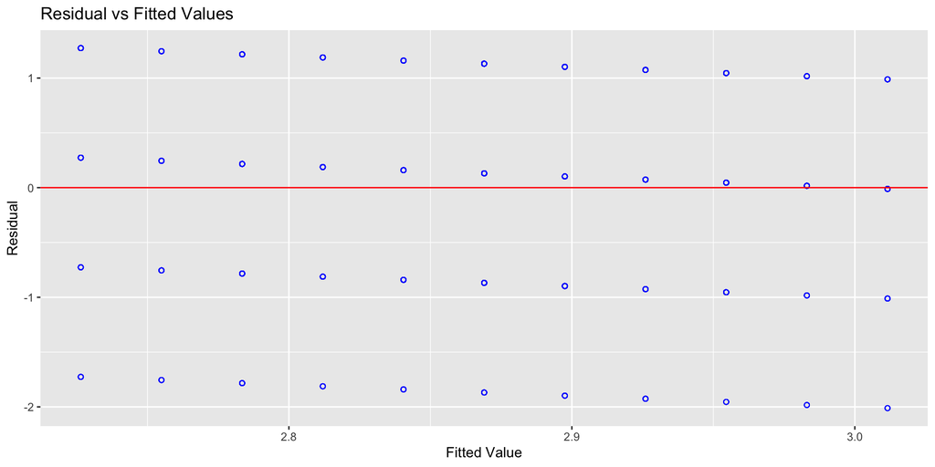

```r
olsrr::ols_plot_resid_fit(modelo_ia_ideo)
```

- Normality of the errors

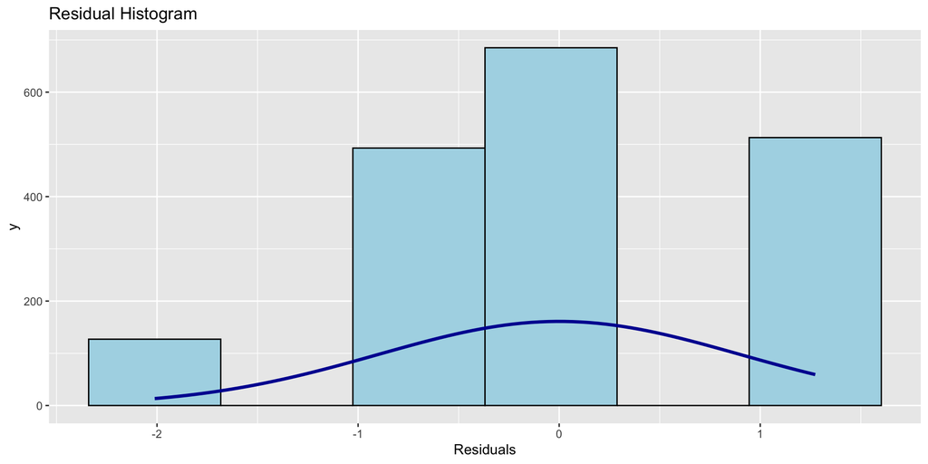

```r
olsrr::ols_plot_resid_hist(modelo_ia_ideo)
```

## Is this causal?

[figure not shown]

[figure not shown]

[figure not shown]

## Causality, omitted-variable bias

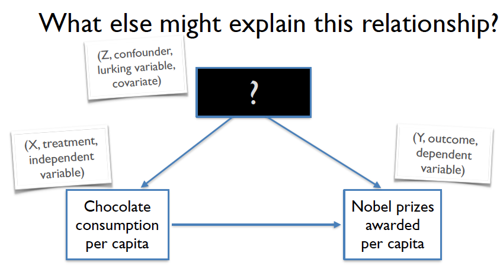

- Is this a *spurious* correlation?
- How do we find the *Z*s? Which ones do you see here?
- How do we reduce **omitted-variable bias**?

## The experimental ideal

- Ideally we would have a treatment assigned at random, so as to understand that the result of our regression captures the causal effect of X on Y
- Random experiments are unlikely in many fields of the social sciences

**The next step**: controlling in order to “*balance*”

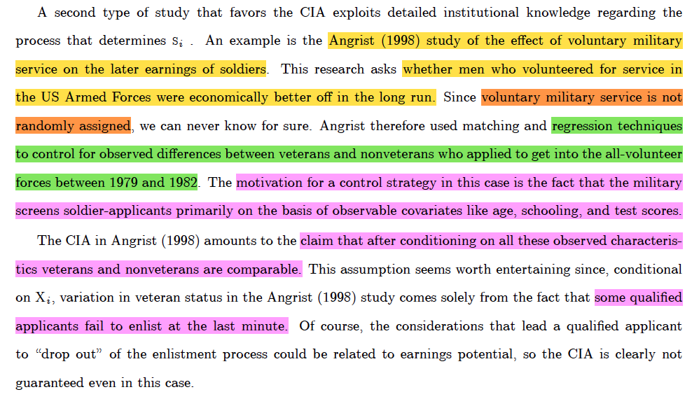

Source: Mostly Harmless Econometrics, p. 47

## Controlling like Boix and Stokes

Boix and Stokes vs. Przeworski

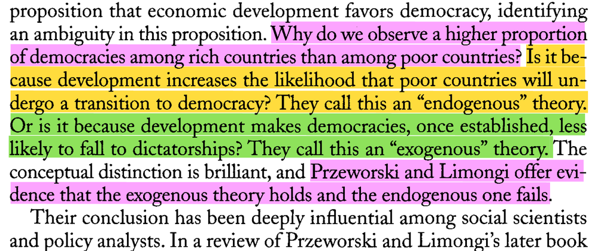

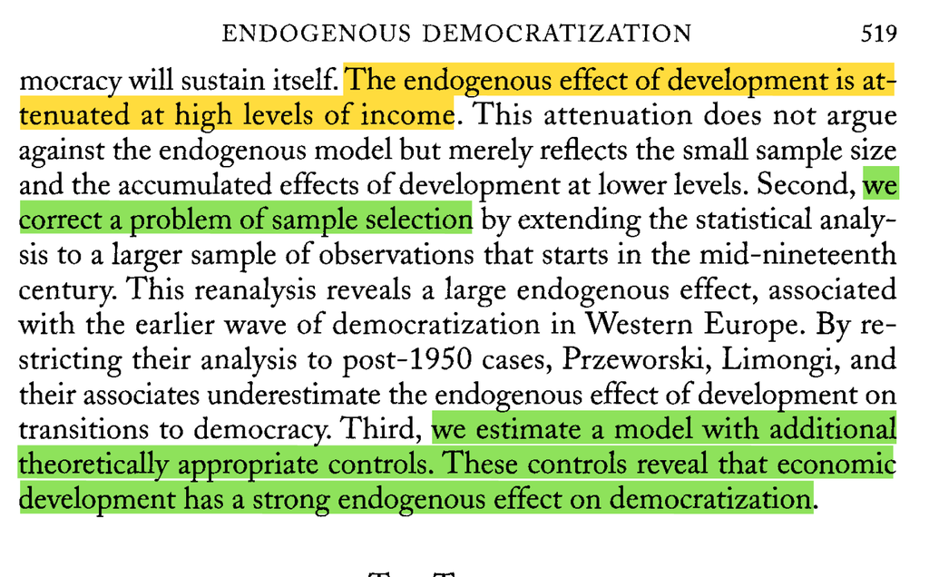

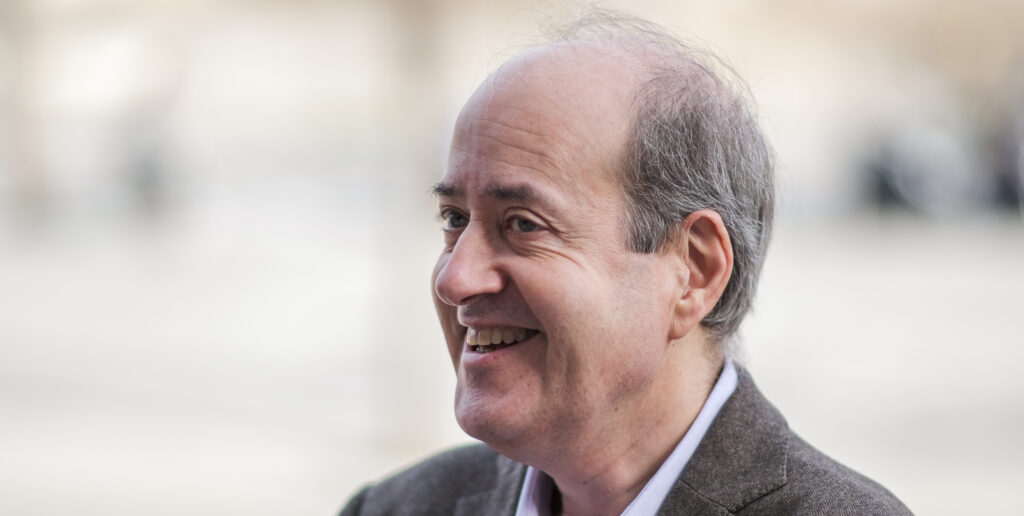

## Wrapping up

- The CLT tells us why a random sample lets us learn about the population, with an uncertainty we can measure with the SE and the CI
- The p-value accompanies almost all our tools, Chi2 for two categorical variables, the t-test for one continuous and one categorical
- Covariance gives us the direction of a relationship, correlation standardizes it and tells us how linear it is
- Regression summarizes that relationship in an interpretable slope, but it is only causal if we have properly controlled for what confounds X and Y
- Next week we will keep controlling

## Questions?

```css
.center h2 {
  text-align: center;
}
```

I’m also here: smsoler@clio.uc3m.es

Research Seminar